# Proyecto Final

#### Ainhoa Calvo Ejerique

```r
library(ggplot2)
library(dplyr)
library(plyr)
```

Con el conjunto de datos diabetes.data

1. Cargar los datos en R.

```r
diabetes_conNA <-read.table("diabetes.data", header = TRUE)
sum(is.na(diabetes_conNA))
```

```
## [1] 0
```

2. Eliminar los missing values, que están codificados como -9999.00.

```r
diabetes_conNA2 <-read.table("diabetes.data",header =TRUE, na.strings = "-9999.0")
sum(is.na(diabetes_conNA2))
```

```
## [1] 10
```

Se han eliminado 10 NA. Y se comprueba que el nuevo df “diabetes” no contiene NA.

```r
diabetes <-na.omit(diabetes_conNA2)
sum(is.na(diabetes))
```

```
## [1] 0
```

3. Ver el tipo de cada una de las variables.

```r
str(diabetes)
```

```
## 'data.frame':    433 obs. of  11 variables:
##  $ AGE: int  59 48 72 24 50 23 36 66 60 29 ...
##  $ SEX: Factor w/ 2 levels "F","M": 1 2 1 2 2 2 1 1 1 2 ...
##  $ BMI: num  32.1 21.6 30.5 25.3 23 22.6 22 26.2 32.1 30 ...
##  $ BP : num  101 87 93 84 101 89 90 114 83 85 ...
##  $ S1 : int  157 183 156 198 192 139 160 255 179 180 ...
##  $ S2 : num  93.2 103.2 93.6 131.4 125.4 ...
##  $ S3 : num  38 70 41 40 52 61 50 56 42 43 ...
##  $ S4 : num  4 3 4 5 4 2 3 4.55 4 4 ...
##  $ S5 : num  4.86 3.89 4.67 4.89 4.29 ...
##  $ S6 : int  87 69 85 89 80 68 82 92 94 88 ...
##  $ Y  : int  151 75 141 206 135 97 138 63 110 310 ...
##  - attr(*, "na.action")=Class 'omit'  Named int [1:9] 19 25 74 86 342 384 421 433 440
##   .. ..- attr(*, "names")= chr [1:9] "19" "25" "74" "86" ...
```

Las variables son de tipo numérico (num e int), con la excepción de SEX que es un factor.

4. Realizar un análisis estadísıstico de las variables: calcular la media, varianza, rangos, etc. ¿Tienen las distintas variables rangos muy diferentes?

Elimino del análisis descriptivo la variable SEX, que es un factor. Utilizo la función apply() para obtener la media, cuartiles y rango, así como la sd -no la varianza que no es un valor comparable-.

```r
dim(diabetes)
```

```
## [1] 433  11
```

```r
apply(diabetes[-2], 2, mean)
```

```
##        AGE        BMI         BP         S1         S2         S3
##  48.475751  26.352194  94.648129 189.260970 115.362818  49.864896
##         S4         S5         S6          Y
##   4.070624   4.645407  91.249423 152.212471
```

```r
apply(diabetes[-2], 2, range)
```

```
##      AGE  BMI  BP  S1    S2 S3   S4     S5  S6   Y
## [1,]  19 18.0  62  97  41.6 22 2.00 3.2581  58  25
## [2,]  79 42.2 133 301 242.4 99 9.09 6.1070 124 346
```

```r
apply(diabetes[-2], 2, quantile, probs=c(0.25, 0.50, 0.75))
```

```
##     AGE  BMI  BP  S1    S2 S3 S4     S5 S6   Y
## 25%  38 23.1  84 164  95.4 40  3 4.2767 83  85
## 50%  50 25.7  93 186 113.0 48  4 4.6347 91 140
## 75%  59 29.2 105 210 134.2 58  5 4.9972 98 214
```

```r
apply(diabetes[-2], 2, sd)
```

```
##        AGE        BMI         BP         S1         S2         S3
## 13.1712365  4.4282031 13.9364285 34.7892967 30.6081829 13.0367488
##         S4         S5         S6          Y
##  1.2998030  0.5251244 11.4739099 77.5470653
```

Se observan rangos muy diferentes para las distintas variables.

5. Hacer un gráfico de cajas (boxplot) dónde se pueda ver la información anterior de forma gráfica.

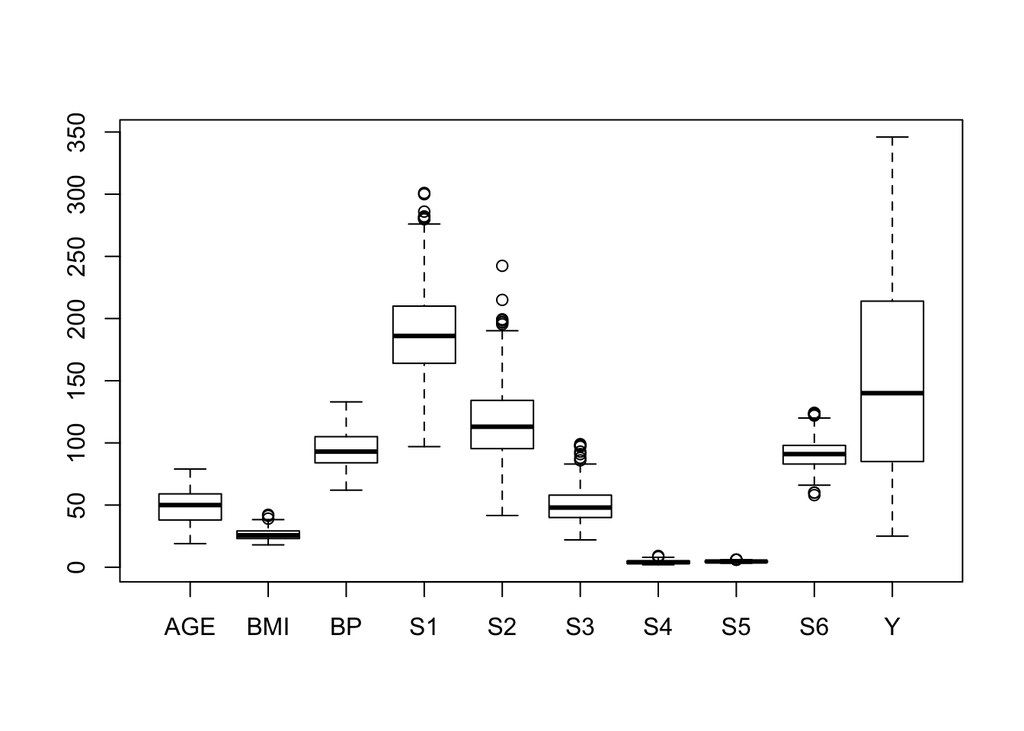

6. Calcular la media para las filas que tienen SEX=M y la media para las filas que tienen SEX=F, utilizando la función tapply.

Aplicaré un equivalent que es la utilización de la función split() y a acontinuación lapply

```r
s <-split(diabetes, diabetes$SEX)
lapply(s, function(diabetes) colMeans(diabetes[,c(-2)]))
```

```
## $F
##        AGE        BMI         BP         S1         S2         S3
##  50.866995  26.800985  98.175616 190.655172 120.110345  44.541872
##         S4         S5         S6          Y
##   4.537882   4.731533  93.862069 155.807882
##
## $M
##        AGE        BMI         BP         S1         S2         S3
##  46.365217  25.956087  91.534739 188.030435 111.172609  54.563043
##         S4         S5         S6          Y
##   3.658217   4.569392  88.943478 149.039130
```

7. Calcular la correlación de todas las variables numéricas con la variable Y.

```r
corr_y<-cor(diabetes[-2])[,10]
corr_y[-10]
```

```
##        AGE        BMI         BP         S1         S2         S3
##  0.1889540  0.5863673  0.4398515  0.2133325  0.1747189 -0.3963076
##         S4         S5         S6
##  0.4325640  0.5703164  0.3892246
```

La máxima correlación de Y se observa con BMI, y la mínima con S2 y AGE.

8. Realizar un gráfico de dispersión para las variables que tienen más y menos correlación con Y y comentar los resultados. ¿Como sería el gráfico de dispersión entre dos cosas con correlación 1?

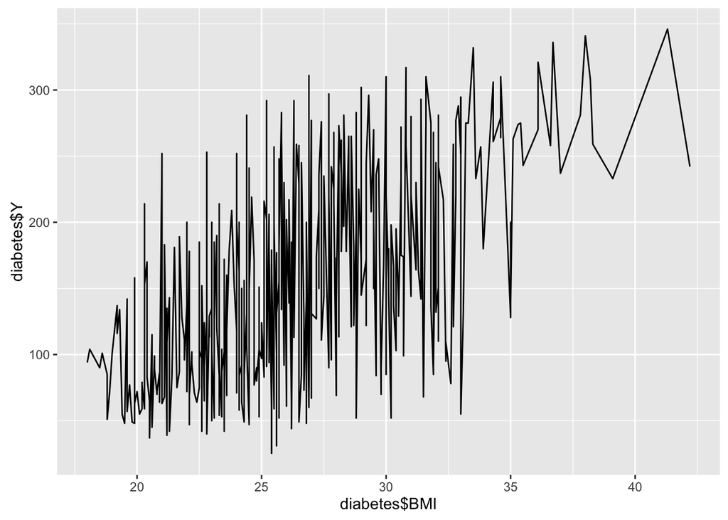

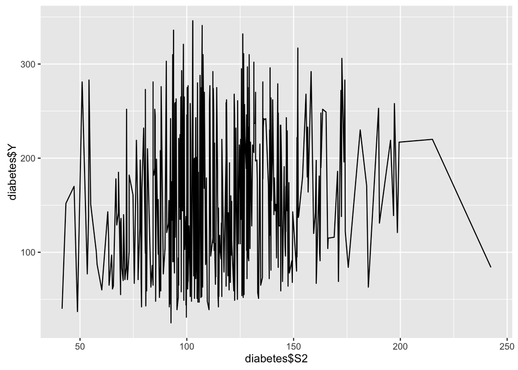

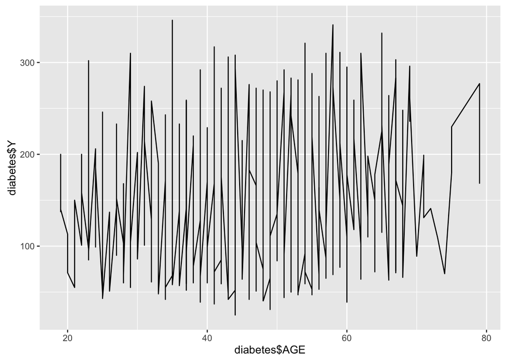

El gráfico de dispersión entre dos varaibles con correlación 1, sería como el representado abajo, en el que se realiza un gráfico de dispersión entre Y e Y. Es decir, una línea de 45 grados.

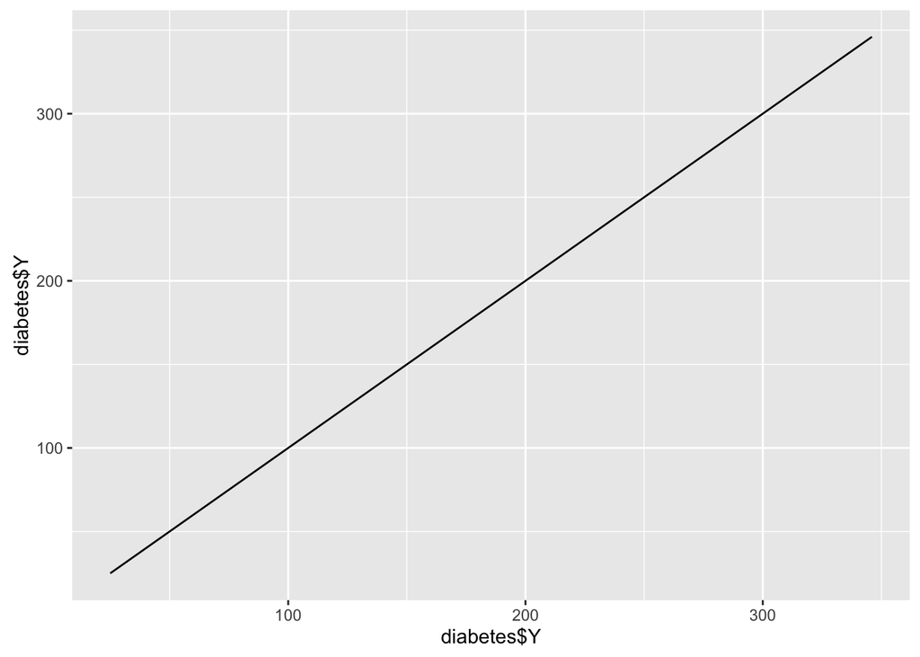

9. Transformar la variable SEX, que es un factor, en una variable numérica utilizando, por ejemplo, la codificación M=1 y F=2.

```r
diabetes_sinfactor<-diabetes %>% mutate(SEXnum = ifelse(SEX=="M", 1, 2))
diabetes_sinfactor <-diabetes_sinfactor %>% select(-c(diabetes_sinfactor$SEX))
```

10. Definimos los outliers como los elementos (filas) de los datos para los que cualquiera de las variables está por encima o por debajo de la mediana más/menos 3 veces el MAD (Median Absolute Deviation). Identificar estos outliers y quitarlos.

```r
findOutlier <- function(data, corte = 3) {
    ## Calcula la mediana y la mad
    medians <- apply(data, 2, median, na.rm = TRUE)
    madr <- apply(data,2, mad, na.rm=TRUE)
    ## Identifica las celdas que son outliers, con corte por defecto=3
    result <- mapply(function(d, s, r) {
        which(d > s+corte*r|d < s-corte*r)
    }, data, medians,madr)
    result
}

outliers <- findOutlier(diabetes[-2])
outliers
```

```
## $AGE
## integer(0)
##
## $BMI
## [1] 253 362 363
##
## $BP
## integer(0)
##
## $S1
## [1] 120 227
##
## $S2
## [1] 120 158 227 372
##
## $S3
## [1]  57 257 258 266 433
##
## $S4
## [1] 120
##
## $S5
## integer(0)
##
## $S6
## [1]  23 114 138 346 401 422
##
## $Y
## integer(0)
```

```r
removeOutlier <- function(data, outliers) {
    result <- mapply(function(d, o) {
        res <- d
        res[o] <- NA
        return(res)
    }, data, outliers)
    return(as.data.frame(result))
}

dataFilt <- removeOutlier(diabetes[-2], outliers)
dataFilt2 <-na.omit(dataFilt)
```

En total se han eliminado 18 filas.

11. Separar el conjunto de datos en dos, el primero (entrenamiento) conteniendo un 70% de los datos y el segundo (test) un 30%, de forma aleatoria.

```r
smp_size <- floor(0.70 * nrow(dataFilt2))
```

Escojo de manera aleatoria los grupos. Fijo una semilla para que la formación de grupos sea reproducible.

```r
set.seed(5)
train_s <- sample(seq_len(nrow(dataFilt2)), size=smp_size)
```

```r
train <-dataFilt2[train_s, ]
test <-dataFilt2[-train_s, ]
dim(train)
```

```
## [1] 290  10
```

```r
dim(test)
```

```
## [1] 125  10
```

12. Escalar los datos para que tengan media 0 y varianza 1, es decir, restar a cada variable numérica su media y dividir por la desviaciónon típica. Calcular la media y desviación en el conjunto de train, y utilizar esa misma media y desviación para escalar el conjunto de test.

En primer lugar, hay que construir un método para normalizar los dos grupos con los parámetros de normalización elegidos (media y desviación standard de train)

```r
normaliza =  function(dF, param){
    as.data.frame(
      Map(function(columna, paramn){
          (columna-paramn[1])/(paramn[2])
    },dF,
    param)
    )
  }
```

En segundo lugar, hay que obtener los parámetros que se aplicarán en la normalización.

```r
  param1 = numcolwise(mean) (train)
  param2= numcolwise (sd) (train)
  param =rbind(param1,param2)
```

En tercer lugar, se aplica la función normaliza con los parámetros obtenidos del df train a los dos grupos

```r
train_normalizado = normaliza(train, param)
test_normalizado = normaliza(test, param)
```

En último lugar, se comprueba que el proceso de normalización ha funcinado, mediante el cálculo de medias y sd de cada uan de las varaibles, y mediante boxplot.

```r
apply(train_normalizado,2,mean)
```

```
##           AGE           BMI            BP            S1            S2
##  1.505392e-16 -3.532256e-17 -3.597727e-16  3.250132e-16  2.044551e-16
##            S3            S4            S5            S6             Y
##  2.915582e-16  2.600167e-16 -5.652952e-16  5.127211e-17 -5.784854e-17
```

```r
apply(train_normalizado,2,sd)
```

```
## AGE BMI  BP  S1  S2  S3  S4  S5  S6   Y
##   1   1   1   1   1   1   1   1   1   1
```

```r
apply(test_normalizado,2,mean)
```

```
##          AGE          BMI           BP           S1           S2
##  0.034242059  0.078444817  0.104707934  0.023041833 -0.003547012
##           S3           S4           S5           S6            Y
##  0.137069412 -0.100728809 -0.054900607 -0.020018147  0.129085557
```

```r
apply(test_normalizado,2,sd)
```

```
##       AGE       BMI        BP        S1        S2        S3        S4
## 0.9702669 0.9859068 0.9593174 0.9848473 0.9578850 1.1647328 1.0039611
##        S5        S6         Y
## 0.9908862 0.9001299 0.9506822
```

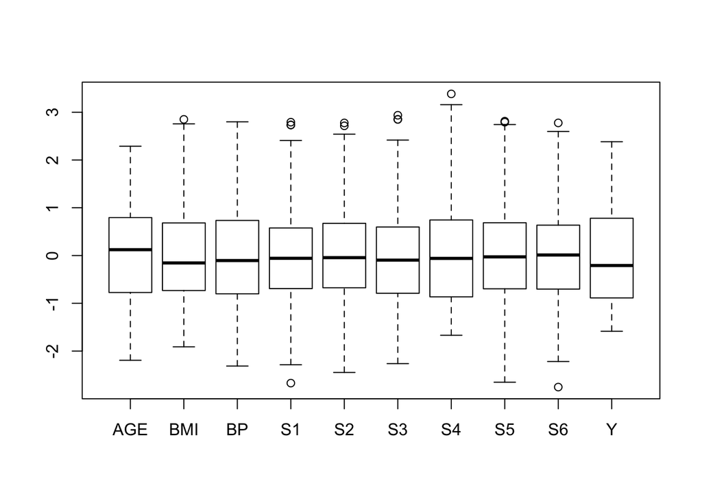

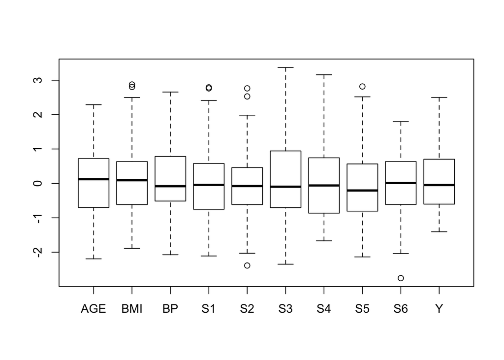

13. (Opcional) Realizar un modelo de regresión lineal de la variable de respuesta sobre el resto y ajustarlo por mínimos cuadrados usando únicamente los datos del conjunto de entrenamiento.

```r
regresion <- lm(Y~ ., data=train)
summary(regresion)
```

```
##
## Call:
## lm(formula = Y ~ ., data = train)
##
## Residuals:
##      Min       1Q   Median       3Q      Max
## -143.147  -40.373   -2.796   38.286  149.791
##
## Coefficients:
##               Estimate Std. Error t value Pr(>|t|)
## (Intercept) -381.71158   92.11134  -4.144 4.53e-05 ***
## AGE           -0.02994    0.27368  -0.109 0.912970
## BMI            6.05143    0.95259   6.353 8.54e-10 ***
## BP             1.01223    0.28066   3.607 0.000367 ***
## S1            -0.76730    0.76249  -1.006 0.315135
## S2             0.62799    0.68361   0.919 0.359079
## S3             0.26204    1.12699   0.233 0.816307
## S4            -1.52702    8.20841  -0.186 0.852556
## S5            73.66417   19.89558   3.703 0.000257 ***
## S6             0.01135    0.35131   0.032 0.974248
## ---
## Signif. codes:  0 '***' 0.001 '**' 0.01 '*' 0.05 '.' 0.1 ' ' 1
##
## Residual standard error: 55.53 on 280 degrees of freedom
## Multiple R-squared:  0.5009, Adjusted R-squared:  0.4848
## F-statistic: 31.22 on 9 and 280 DF,  p-value: < 2.2e-16
```

Como puede verse en los p-values tan solo cuatro de los estimadores (el intercept y tres betas) son significativas. El adjusted R-squared no es bueno.

```r
y_pred <- predict.lm(regresion, newdata=dataFilt2)
mse <- mean((dataFilt2$Y-y_pred)^2)
cat("Mean squared error:", mse, "\n")
```

```
## Mean squared error: 3034.799
```